# NYPD Shooting Incident Severity Analysis

2023-08-18

# Introduction

In this report I correlate the severity of NYPD Shooting Incident(Fatal, Non-fatal) with administrative unit(Borough) and victim’s demographics(Age, Sex and Race).

# Importing the libraries

```r
library(tidyverse)
library(lubridate)
library(ggthemes)
library(glm2)
```

# Importing and summarize the data

The variables that I used in the analysis appeared not to have any missing values. Here is the list of variables and their corresponding description that I used in the analysis. - BORO: Borough where the incident occurred. - OCCUR_DATE: Month, day, and year in which the shooting incident occurred. - OCCUR_TIME: Time of day in which the shooting incident occurred. - STATISTCAL_MUREDER_FLAG: Record stating whether a shooting resulted in the victim’s death. - VIC_SEX: Victim’s gender - VIC_RACE: Victim’s race as categorized by the New York City Police Department. - VIC_AGE_GROUP: Victim’s age group as categorized by the New York City Police Department.

```r
url = 'https://data.cityofnewyork.us/api/views/833y-fsy8/rows.csv?accessType=DOWNLOAD'
data = read_csv(url)
summary(data)
```

```
##   INCIDENT_KEY        OCCUR_DATE         OCCUR_TIME           BORO
##  Min.   :  9953245   Length:27312       Length:27312      Length:27312
##  1st Qu.: 63860880   Class :character   Class1:hms        Class :character
##  Median : 90372218   Mode  :character   Class2:difftime   Mode  :character
##  Mean   :120860536                      Mode  :numeric
##  3rd Qu.:188810230
##  Max.   :261190187
##
##  LOC_OF_OCCUR_DESC     PRECINCT      JURISDICTION_CODE LOC_CLASSFCTN_DESC
##  Length:27312       Min.   :  1.00   Min.   :0.0000    Length:27312
##  Class :character   1st Qu.: 44.00   1st Qu.:0.0000    Class :character
##  Mode  :character   Median : 68.00   Median :0.0000    Mode  :character
##                     Mean   : 65.64   Mean   :0.3269
##                     3rd Qu.: 81.00   3rd Qu.:0.0000
##                     Max.   :123.00   Max.   :2.0000
##                                      NA's   :2
##  LOCATION_DESC      STATISTICAL_MURDER_FLAG PERP_AGE_GROUP
##  Length:27312       Mode :logical           Length:27312
##  Class :character   FALSE:22046             Class :character
##  Mode  :character   TRUE :5266              Mode  :character
##
##
##
##
##    PERP_SEX          PERP_RACE         VIC_AGE_GROUP        VIC_SEX
##  Length:27312       Length:27312       Length:27312       Length:27312
##  Class :character   Class :character   Class :character   Class :character
##  Mode  :character   Mode  :character   Mode  :character   Mode  :character
##
##
##
##
##    VIC_RACE           X_COORD_CD        Y_COORD_CD        Latitude
##  Length:27312       Min.   : 914928   Min.   :125757   Min.   :40.51
##  Class :character   1st Qu.:1000029   1st Qu.:182834   1st Qu.:40.67
##  Mode  :character   Median :1007731   Median :194487   Median :40.70
##                     Mean   :1009449   Mean   :208127   Mean   :40.74
##                     3rd Qu.:1016838   3rd Qu.:239518   3rd Qu.:40.82
##                     Max.   :1066815   Max.   :271128   Max.   :40.91
##                                                        NA's   :10
##    Longitude        Lon_Lat
##  Min.   :-74.25   Length:27312
##  1st Qu.:-73.94   Class :character
##  Median :-73.92   Mode  :character
##  Mean   :-73.91
##  3rd Qu.:-73.88
##  Max.   :-73.70
##  NA's   :10
```

# Mutate some variables for analysis

- I created variables such as hour, year and incident type that I used later in the analysis.

```r
data_a <- data %>%
  mutate(hour = as.numeric(substr(OCCUR_TIME, 1,2)),
         year = year(mdy(OCCUR_DATE)),
         categorized_hour = cut(hour,
                                 breaks = c(0, 6, 12, 18, 23),
                                 labels = c('0-6', '7-12', '13-18', '19-23'),
                                 include.lowest = TRUE),
         incident_type = ifelse(STATISTICAL_MURDER_FLAG, "Fatal Incident", "Non-Fatal Incident"),
         incident_type_model = ifelse(STATISTICAL_MURDER_FLAG, 1, 0)
  )
```

# Fatal and non-fatal incident

- I created a plot showing the number of fatal and non-fatal incident in NYPD shooting incident data. Fatal incident constituted 19% of the incidents.

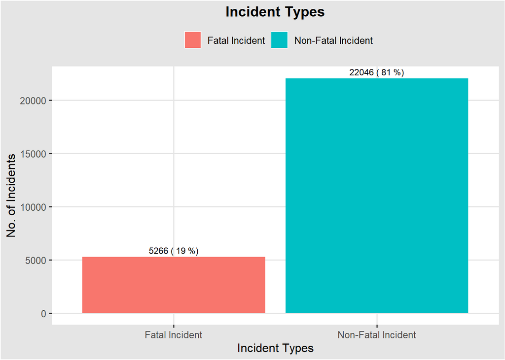

```r
data_a %>%
  group_by(incident_type) %>%
  summarise(count = n()) %>%
  mutate(percent = round((count / sum(count)) * 100),3) %>%
  ggplot(aes(x = incident_type, y = count, fill = incident_type)) +
  geom_bar(stat = "identity") +
  geom_text(aes(label = paste(count, "(", percent, "%)")),
            vjust = -0.5, color = "black", size = 3) +
  labs(title = "Incident Types", y='No. of Incidents',
       x='Incident Types', fill='') +
  theme_igray()+
  theme(plot.title = element_text(hjust = 0.5, face = 'bold'),
        legend.position = 'top')
```

# Fatal and non-fatal incident by race

- Black majority appears to be over represented in both fatal and non-fatal incidents.
- A more unbiased results can be obtained by normalizing the incident with population by each race but the population data was not available.

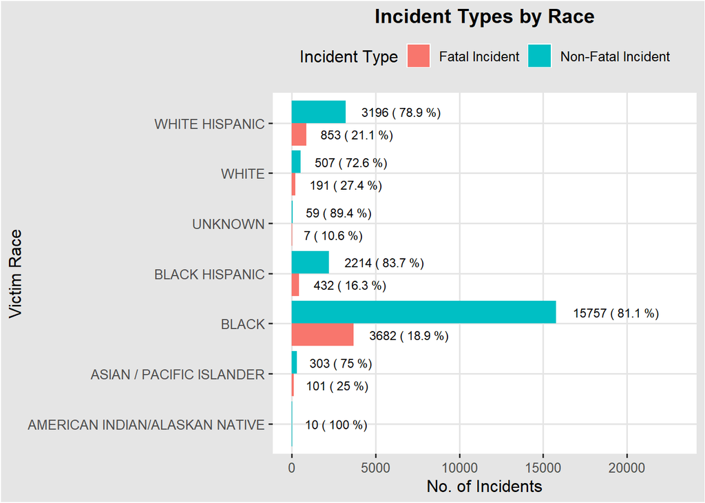

```r
data_a %>%
  #filter(VIC_RACE != "UNKNOWN") %>%
  group_by(VIC_RACE, incident_type) %>%
  summarise(count = n()) %>%
  mutate(percent = round((count / sum(count)) * 100, 1)) %>%
  ggplot(aes(x = count, y = VIC_RACE, fill = incident_type)) +  # Switch x and y aesthetics
  geom_bar(stat = "identity", position = "dodge") +
  geom_text(aes(label = paste(count, "(", percent, "%)")),
            position = position_dodge(width = 0.9),
            hjust = -0.2, color = "black", size = 3) +  # Adjust hjust for horizontal text alignment
  scale_x_continuous(limits = c(0, 23000))+
  labs(title = "Incident Types by Race", x = 'No. of Incidents',  # Adjust x and y labels
       y = 'Victim Race', fill = 'Incident Type') +
  theme_igray() +
  theme(plot.title = element_text(hjust = 0.5, face = 'bold'),
        legend.position = 'top')
```

# Fatal and non-fatal incident by victim’s age group

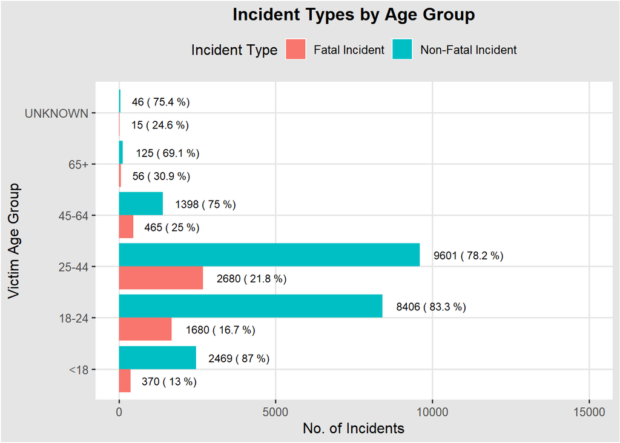

```r
data_a %>%
  filter(VIC_AGE_GROUP != "1022") %>% # One incident with an error
  group_by(VIC_AGE_GROUP, incident_type) %>%
  summarise(count = n()) %>%
  mutate(percent = round((count / sum(count)) * 100, 1)) %>%
  ggplot(aes(x = count, y = VIC_AGE_GROUP, fill = incident_type)) +  # Switch x and y aesthetics
  geom_bar(stat = "identity", position = "dodge") +
  geom_text(aes(label = paste(count, "(", percent, "%)")),
            position = position_dodge(width = 0.9),
            hjust = -0.2, color = "black", size = 3) +  # Adjust hjust for horizontal text alignment
  scale_x_continuous(limits = c(0, 15000))+
  labs(title = "Incident Types by Age Group", x = 'No. of Incidents',  # Adjust x and y labels
       y = 'Victim Age Group', fill = 'Incident Type') +
  theme_igray() +
  theme(plot.title = element_text(hjust = 0.5, face = 'bold'),
        legend.position = 'top')
```

# Fatal and non-fatal incident by victim’s sex

- Male victims constitute majority of the incidents
- The percent of fatal incident within each group are fairly similar.

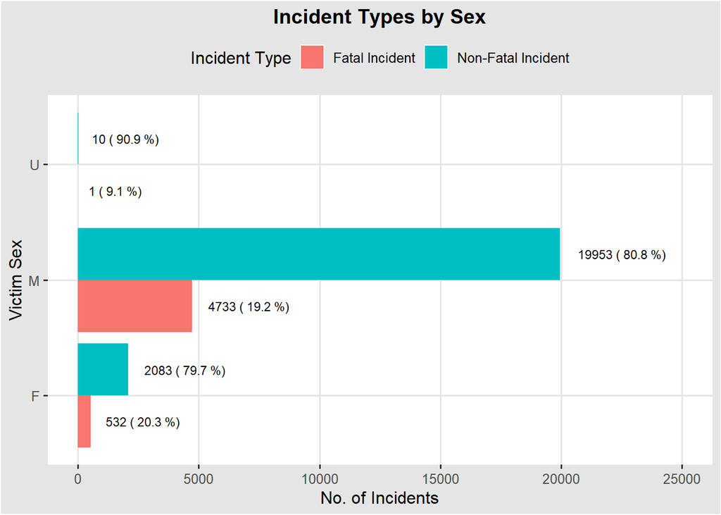

```r
data_a %>%
  filter(VIC_SEX != "1022") %>% # One incident with an error
  group_by(VIC_SEX, incident_type) %>%
  summarise(count = n()) %>%
  mutate(percent = round((count / sum(count)) * 100, 1)) %>%
  ggplot(aes(x = count, y = VIC_SEX, fill = incident_type)) +  # Switch x and y aesthetics
  geom_bar(stat = "identity", position = "dodge") +
  geom_text(aes(label = paste(count, "(", percent, "%)")),
            position = position_dodge(width = 0.9),
            hjust = -0.2, color = "black", size = 3) +  # Adjust hjust for horizontal text alignment
  scale_x_continuous(limits = c(0, 25000))+
  labs(title = "Incident Types by Sex", x = 'No. of Incidents',  # Adjust x and y labels
       y = 'Victim Sex', fill = 'Incident Type') +
  theme_igray() +
  theme(plot.title = element_text(hjust = 0.5, face = 'bold'),
        legend.position = 'top')
```

# Fatal and non-fatal incident by borough

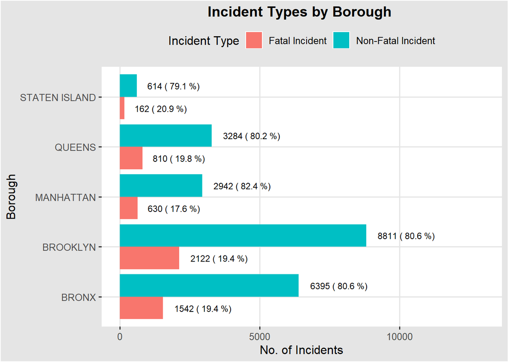

```r
data_a %>%
  group_by(BORO, incident_type) %>%
  summarise(count = n()) %>%
  mutate(percent = round((count / sum(count)) * 100, 1)) %>%
  ggplot(aes(x = count, y = BORO, fill = incident_type)) +  # Switch x and y aesthetics
  geom_bar(stat = "identity", position = "dodge") +
  geom_text(aes(label = paste(count, "(", percent, "%)")),
            position = position_dodge(width = 0.9),
            hjust = -0.2, color = "black", size = 3) +  # Adjust hjust for horizontal text alignment
  scale_x_continuous(limits = c(0, 13000))+
  labs(title = "Incident Types by Borough ", x = 'No. of Incidents',  # Adjust x and y labels
       y = 'Borough', fill = 'Incident Type') +
  theme_igray() +
  theme(plot.title = element_text(hjust = 0.5, face = 'bold'),
        legend.position = 'top')
```

# Fatal and non-fatal incident by hour of the day

- Both Fatal and non-fatal incidents are more prevalent at night time

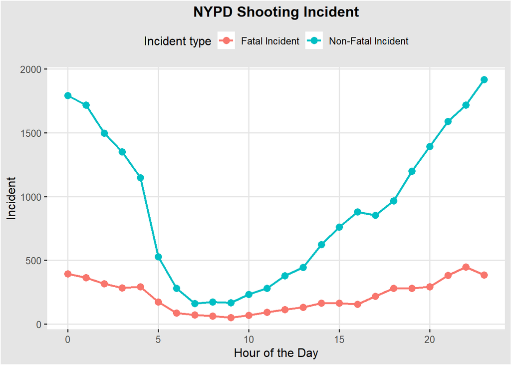

```r
data_a %>%
  group_by(hour, incident_type)%>%
  #Count the number of incidents
  summarise(incident=n())%>%
  ungroup() %>%
  ggplot(aes(x=hour, y=incident, color=incident_type)) +
  geom_line(size=1) +
  geom_point(size=3) +
  theme_igray() +
  theme(plot.title = element_text(hjust = 0.5, face = 'bold'),
        legend.position = 'top')+
  labs(title= "NYPD Shooting Incident",
       x='Hour of the Day', y='Incident', color='Incident type')
```

# Fatal and non-fatal incident by year

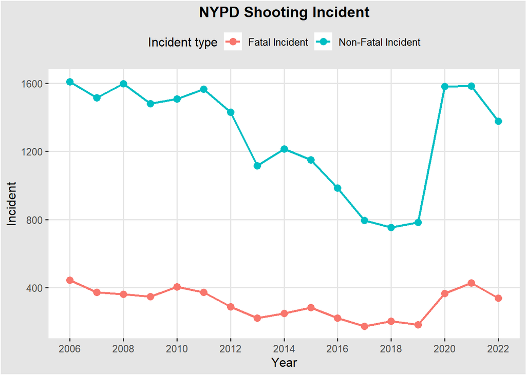

```r
data_a %>%
  group_by(year, incident_type)%>%
  #Count the number of incidents
  summarise(incident=n())%>%
  ungroup() %>%
  ggplot(aes(x=year, y=incident, color=incident_type)) +
  geom_line(size=1) +
  geom_point(size=3) +
  theme_igray() +
  theme(plot.title = element_text(hjust = 0.5, face = 'bold'),
        legend.position = 'top')+
  labs(title= "NYPD Shooting Incident",
       x='Year', y='Incident', color='Incident type')+
  scale_x_continuous(breaks = seq(2006, 2022, by = 2))
```

# MODELING

- I used logistic regression to model the relationship between the severity of incident(fatal or non-fatal) and victims demographics(age, gender, race) and administrative units(borough)
- I used logistic regression because the response variable(fatal vs non-fatal) is binary
- The results shows age group, and administrative unit may have a significant association with the severity of incident. # Convert categorical variables to dummy variables

```r
data_dummies <- model.matrix(~ hour + VIC_SEX + VIC_RACE + VIC_AGE_GROUP + BORO - 1, data_a)
response_var =data_a$incident_type_model
```

# Fit logistic regression model and summarize

```r
logistic_model <- glm(response_var ~ data_dummies, family = binomial(link = "logit"))
summary(logistic_model)
```

```
##
## Call:
## glm(formula = response_var ~ data_dummies, family = binomial(link = "logit"))
##
## Deviance Residuals:
##     Min       1Q   Median       3Q      Max
## -0.9805  -0.6993  -0.6086  -0.5294   2.3313
##
## Coefficients: (1 not defined because of singularities)
##                                                Estimate Std. Error z value
## (Intercept)                                  -1.344e+01  1.020e+02  -0.132
## data_dummieshour                              9.884e-04  1.829e-03   0.540
## data_dummiesVIC_SEXF                          5.747e-01  1.084e+00   0.530
## data_dummiesVIC_SEXM                          5.257e-01  1.083e+00   0.486
## data_dummiesVIC_SEXU                                 NA         NA      NA
## data_dummiesVIC_RACEASIAN / PACIFIC ISLANDER  1.130e+01  1.020e+02   0.111
## data_dummiesVIC_RACEBLACK                     1.102e+01  1.020e+02   0.108
## data_dummiesVIC_RACEBLACK HISPANIC            1.084e+01  1.020e+02   0.106
## data_dummiesVIC_RACEUNKNOWN                   1.026e+01  1.020e+02   0.101
## data_dummiesVIC_RACEWHITE                     1.135e+01  1.020e+02   0.111
## data_dummiesVIC_RACEWHITE HISPANIC            1.114e+01  1.020e+02   0.109
## data_dummiesVIC_AGE_GROUP1022                -1.055e+01  3.241e+02  -0.033
## data_dummiesVIC_AGE_GROUP18-24                2.867e-01  6.208e-02   4.618
## data_dummiesVIC_AGE_GROUP25-44                6.156e-01  6.021e-02  10.225
## data_dummiesVIC_AGE_GROUP45-64                7.614e-01  7.787e-02   9.778
## data_dummiesVIC_AGE_GROUP65+                  1.018e+00  1.715e-01   5.933
## data_dummiesVIC_AGE_GROUPUNKNOWN              8.732e-01  3.167e-01   2.757
## data_dummiesBOROBROOKLYN                     -2.154e-02  3.877e-02  -0.556
## data_dummiesBOROMANHATTAN                    -1.367e-01  5.264e-02  -2.598
## data_dummiesBOROQUEENS                       -2.367e-02  4.950e-02  -0.478
## data_dummiesBOROSTATEN ISLAND                 3.074e-02  9.420e-02   0.326
##                                              Pr(>|z|)
## (Intercept)                                   0.89519
## data_dummieshour                              0.58902
## data_dummiesVIC_SEXF                          0.59597
## data_dummiesVIC_SEXM                          0.62726
## data_dummiesVIC_SEXU                               NA
## data_dummiesVIC_RACEASIAN / PACIFIC ISLANDER  0.91180
## data_dummiesVIC_RACEBLACK                     0.91398
## data_dummiesVIC_RACEBLACK HISPANIC            0.91536
```

[output cut: 8 more lines]

```
## data_dummiesVIC_AGE_GROUPUNKNOWN              0.00583 **
## data_dummiesBOROBROOKLYN                      0.57850
## data_dummiesBOROMANHATTAN                     0.00939 **
## data_dummiesBOROQUEENS                        0.63256
## data_dummiesBOROSTATEN ISLAND                 0.74417
## ---
## Signif. codes:  0 '***' 0.001 '**' 0.01 '*' 0.05 '.' 0.1 ' ' 1
##
## (Dispersion parameter for binomial family taken to be 1)
##
##     Null deviance: 26781  on 27311  degrees of freedom
## Residual deviance: 26496  on 27292  degrees of freedom
## AIC: 26536
##
## Number of Fisher Scoring iterations: 11
```

# Source of bias

The NYPD Shooting Incident data, be subject to various sources of bias that can impact the accuracy and representativeness of the reported information. Such bias may include: - Unreported or undocumented incident might lead to an underrepresentation of the true number of shooting incidents. - The dataset may have not included incidents from all neighborhoods or communities equally. - The data had incomplete information in some of the variable which could lead to a lack of context and potential misinterpretation

# Conclusion:

These findings provide valuable insights into the relationship between incident severity, victim demographics, and temporal trends within the context of NYPD Shooting Incidents.